# Exercises for Exploratory analysis of RNAseq data

[back to lesson’s homepage](https://tavareshugo.github.io/data-carpentry-rnaseq/)

# 1 Intro

## 1.1 Import data

1. Import the four CSV files into R and store in the following objects: `raw_cts`, `trans_cts`, `sample_info` and `test_result`.
2. How many samples are there? Was the design balanced (i.e. do all samples have the same number of replicates)?
3. How many genes do you have gene expression levels for?

```r
# 1. Import data
raw_cts <- read_csv("./data/counts_raw.csv")
trans_cts <- read_csv("./data/counts_transformed.csv")
sample_info <- read_csv("./data/sample_info.csv")
test_result <- read_csv("./data/test_result.csv")

# 2. number of samples is in the "sample_info" table
nrow(sample_info)

# 4. this can be taken from the table of counts
nrow(trans_cts)
```

# 2 Exploratory analysis of count data

## 2.1 Reshape table

Convert the `raw_cts` table to a “long” format using the `pivot_longer()` function. Save it into an object called `raw_cts_long`.

```r
raw_cts_long <- raw_cts %>%
  pivot_longer(wt_0_r1:mut_180_r3, names_to = "sample", values_to = "cts")
```

## 2.2 Join tables

- Take the `raw_cts_long` object created in the previous exercise and *join* it with the `sample_info` table.
- Produce the plot below for the raw count data. (hint: you might want to try log-transforming the x-axis data using the `log10()` function).

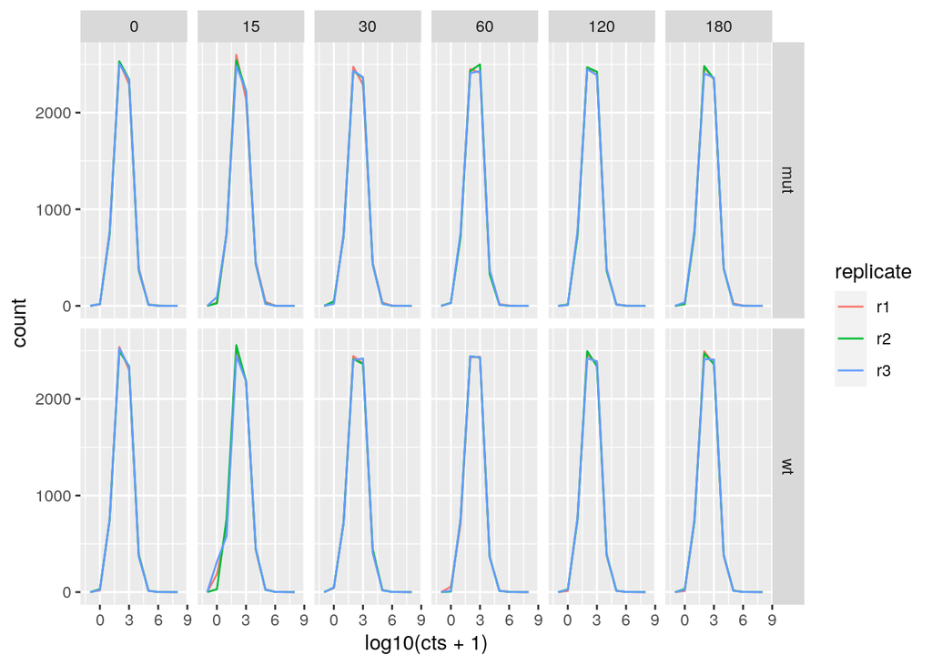

```r
# Join with sample information table
raw_cts_long <- full_join(raw_cts_long, sample_info, by = ("sample"))

# Make the plot
raw_cts_long %>%
  # add pseudo-count of 1 because log(0) = -Inf
  ggplot(aes(log10(cts + 1), colour = replicate)) +
  geom_freqpoly(binwidth = 1) +
  facet_grid(rows = vars(strain), cols = vars(minute))
```

- Try out other ways to visualise these data, for example as a boxplot.

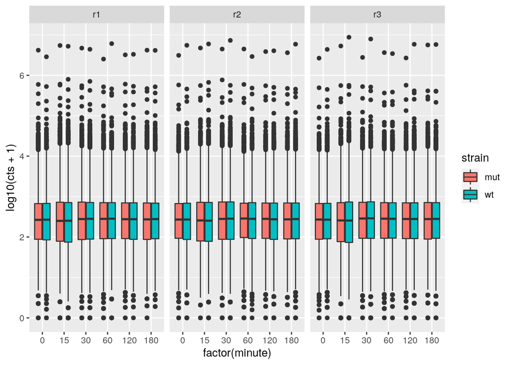

```r
# Make a boxplot
raw_cts_long %>%
  # make sure minute is specified as a factor
  ggplot(aes(factor(minute), log10(cts + 1), fill = strain)) +
  geom_boxplot() +
  facet_grid(cols = vars(replicate))
```

## 2.3 Scatterplot

Compare the expression between a WT cell at T0 and T30. What can you conclude from this?

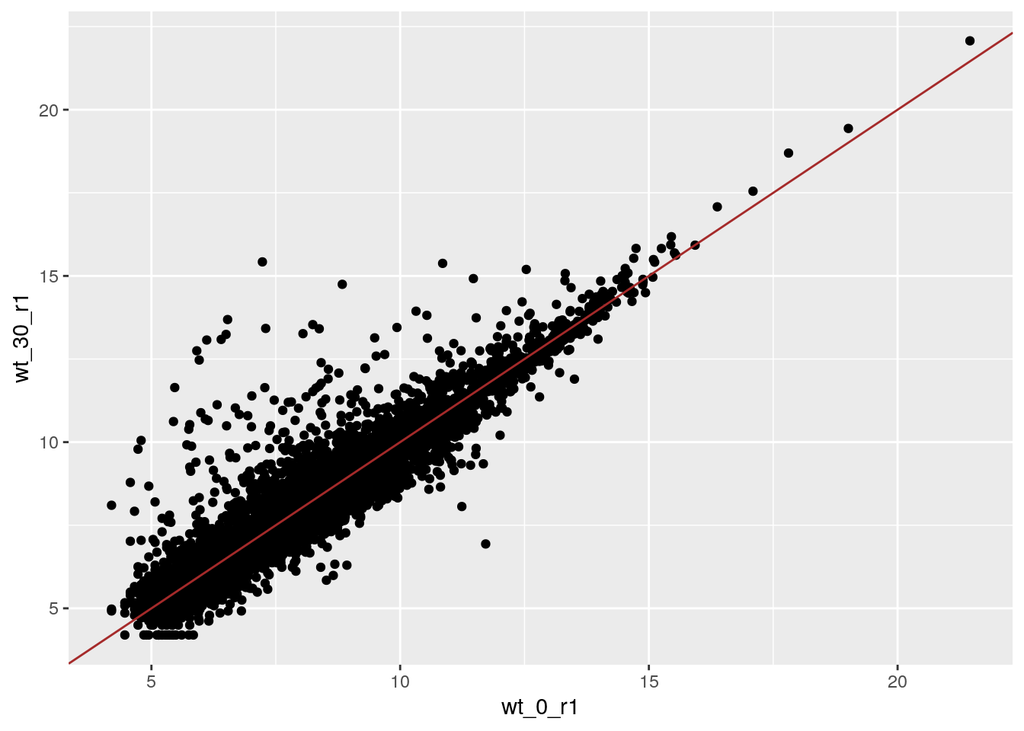

```r
# Scatterplot between T0 and T30
# the correlation is lower than between replicates at T0, for example
trans_cts %>%
  ggplot(aes(wt_0_r1, wt_30_r1)) + geom_point() +
  geom_abline(colour = "brown")
```

# 3 PCA

## 3.1 Examine `prcomp()` output

After running the PCA investigate:

1. What type of object is it? (hint: `class()`)
2. What is the *structure* of this object? (hint: `str()`)
3. Look at the `prcomp()` help page to identify which parts of the object contain the *PC scores*, *eigenvalues* and *variable loadings*? (hint: look under the section “Value” of the help page). As a reminder:
   - *PC scores*: new coordinates of the data on the PC axis
   - *eigenvalues*: variance explained by each PC
   - *variable loadings*: “weight” that each original gene has on each PC axis
4. Extract these three elements from the object? (hint: use `$`)
   - Save the output in objects called `pc_scores`, `pc_eigenvalues` and `pc_loadings`
   - what class is each of these elements?
5. How many principal components do you have?

```r
# 1. class of the object
class(sample_pca)

# 2. structure of the object
str(sample_pca)

# 3. checking the help ?prcomp, under the section "Value" is says:
# "sdev" contains the standard deviation explained by each PC, so if we square it we get the eigenvalues (or explained variance)
# "rotation" contains the variable loadings for each PC, which define the eigenvectors
# "x" contains the PC scores, i.e. the data projected on the new PC axis
# "center" in this case contains the mean of each gene, which was subtracted from each value
# "scale" contains the value FALSE because we did not scale the data by the standard deviation

# 4. we can use the 'dollar sign' to access these elements
pc_scores <- sample_pca$x              # PC scores (a matrix)
pc_eigenvalues <- sample_pca$sdev^2    # eigenvalues (a vector) - notice we square the values
pc_loadings <- sample_pca$rotation     # variable loadings (a matrix)

# 5. here's three ways to check this
ncol(pc_scores)
length(pc_eigenvalues)
ncol(pc_loadings)
```

## 3.2 Annotating PC plot

Fix the following code (where the word FIXME appears), to recreate the plot below. Once the code is fixed, assign (`<-`) the result to an object called `pca_plot`.

What can you conclude from this result?

```
# get the PC scores from prcomp object
sample_pca$x %>%
  # convert it to a tibble
  as_tibble(rownames = "sample") %>%
  # join with "sample_info" table
  FIXME(sample_info, by = "FIXME") %>%
  # make the plot
  ggplot(aes(x = PC1, y = PC2,
             FIXME = factor(minute), shape = FIXME)) +
  geom_point()
```

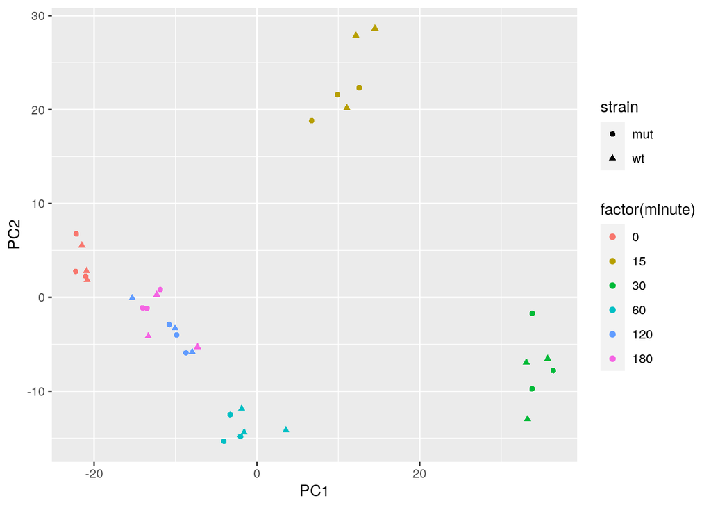

```r
pca_plot <- sample_pca$x %>% # extract the loadings from prcomp
  # convert to a tibble retaining the sample names as a new column
  as_tibble(rownames = "sample") %>%
  # join with "sample_info" table
  full_join(sample_info, by = "sample") %>%
  # create the plot
  ggplot(aes(x = PC1, y = PC2, colour = factor(minute), shape = strain)) +
  geom_point()

# print the result (in this case a ggplot)
pca_plot
```

## 3.3 Visualise variable loadings

Fix the following code (where the word FIXME appears), to recreate the plot below. Once the code is fixed, assign (`<-`) the result to an object called `loadings_plot`.

```
ggplot(data = top_loadings) +
  geom_segment(aes(x = 0, y = 0, xend = PC1, yend = FIXME),
               arrow = arrow(length = unit(0.1, "in")),
               FIXME = "brown") +
  geom_text(aes(x = FIXME, y = PC2, label = gene),
            nudge_y = 0.005, size = 3) +
  scale_x_continuous(expand = c(0.02, 0.02))
```

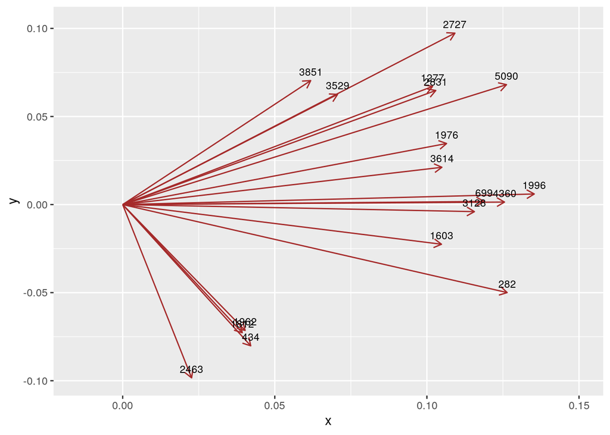

```r
loadings_plot <- ggplot(data = top_loadings) +
  geom_segment(aes(x = 0, y = 0, xend = PC1, yend = PC2),
               arrow = arrow(length = unit(0.1, "in")),
               colour = "brown") +
  geom_text(aes(x = PC1, y = PC2, label = gene),
            nudge_y = 0.005, size = 3) +
  scale_x_continuous(expand = c(0.02, 0.02))
loadings_plot
```

# 4 Exploring test results

## 4.1 MA plot

1. Recreate the plot below from the `test_result` table. (hint: notice the x-axis is log-transformed)
2. Why is the fold-change log transformed?

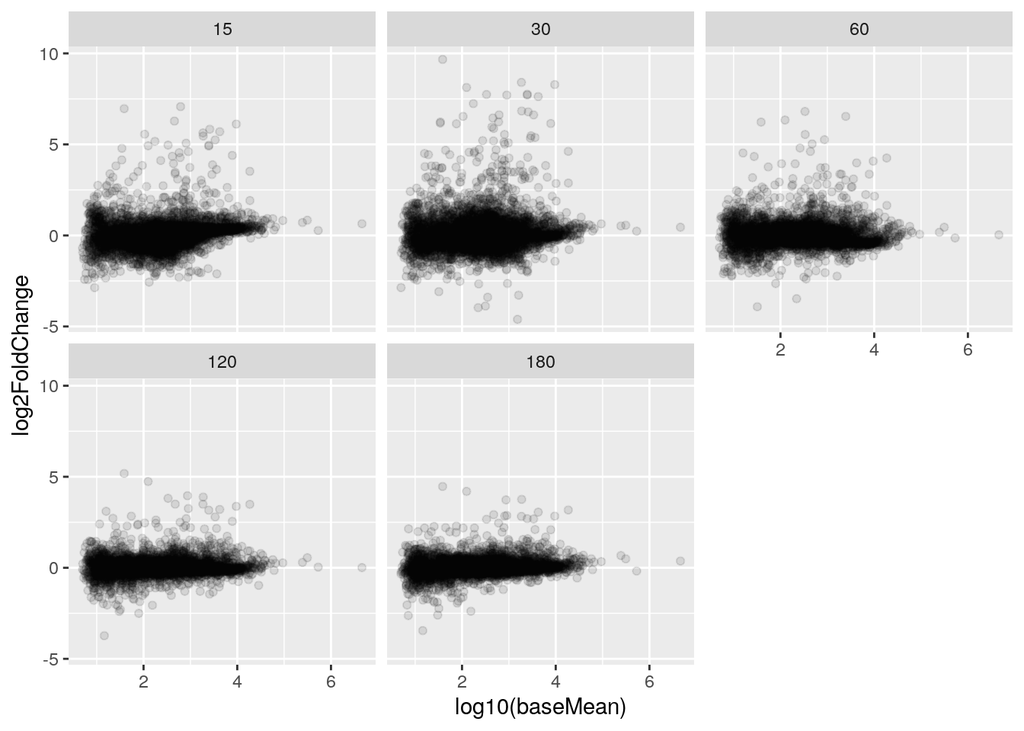

```r
# 1. making the MA plot
test_result %>%
  ggplot(aes(log10(baseMean), log2FoldChange)) +
  geom_point(alpha = 0.1) +
  facet_wrap(vars(comparison))
```

```r
# 2. The reason fold change is log-transformed is:
# Because a fold-change (FC) is a ratio between two things FC = a/b
# if a > b, then the FC can vary from 1 to infinity!
# but if a < b, then it can only go from 0 to 1
# therefore, ratios are not symmetric around equality (a = b)
# taking the log of a ratio solves this problem!
# For example:
# 4/1 = 4     and  log2(4/1) =  2
# 1/4 = 0.25  and  log2(1/4) = -2
# Note that another common example where log-transformation should always be used is RT-qPCR data!
```

**Bonus:** try and re-create the plot below where the x-axis is on a log-scale but showing the original units and genes with an adjusted p-value below 0.01 are highlighted in red. (hint: the function `ifelse()` is useful here. This may be hard if you’re new with R: but look at the solution and see if you can understand the trick we’re using.)

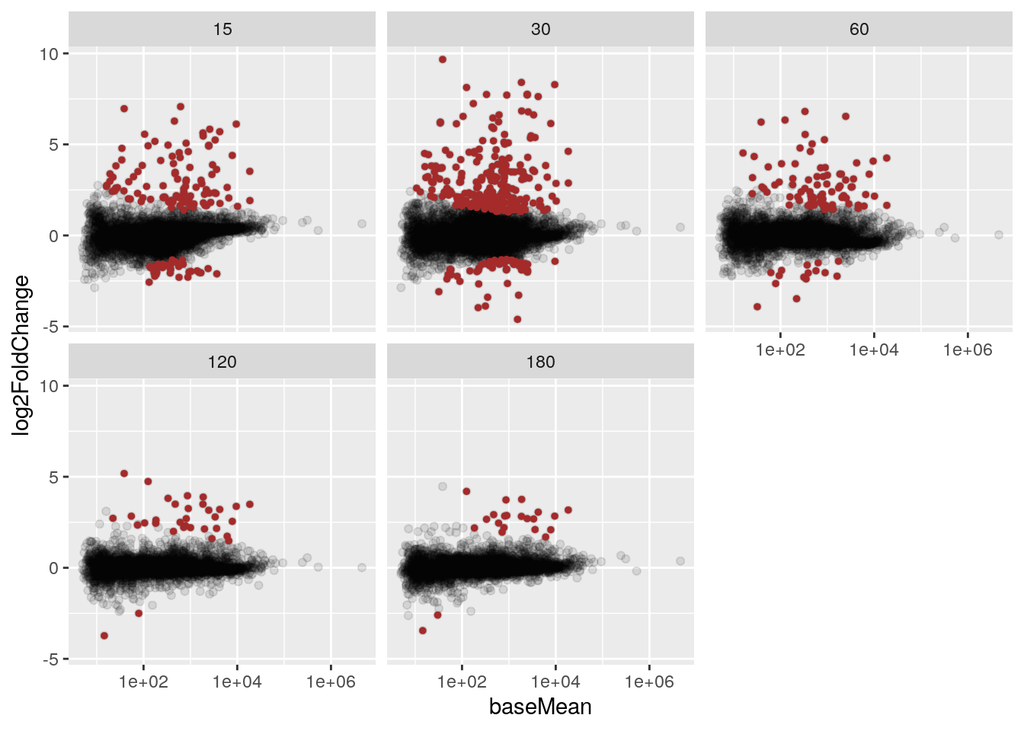

```r
test_result %>%
  # add column which contains value only if padj < 0.01
  mutate(sig = ifelse(padj < 0.01, log2FoldChange, NA)) %>%
  # make the plot
  ggplot(aes(baseMean, log2FoldChange)) +
  geom_point(alpha = 0.1) +
  geom_point(aes(y = sig), colour = "brown", size = 1) +
  scale_x_continuous(trans = "log10") +
  facet_wrap(vars(comparison))
```